# Project D - The Relationship of SES and Reading Scores of High School Seniors

*Figure 4. Boxplot for Standardized Social Studies Scores.*

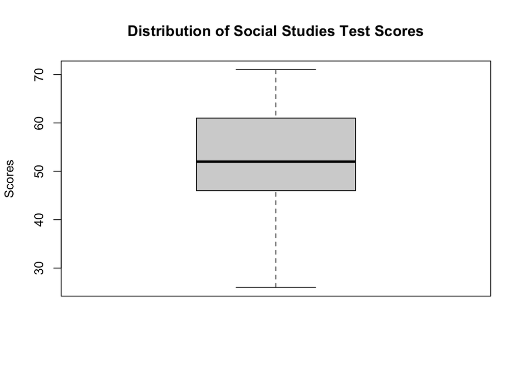

*Table 4. Statistics for Standardized Social Studies Scores.*

```
##       Mean   SD Min Q1 Median Q3 Max
## Socst 52.4 10.7  26 46     52 61  71
```

*Figure 5. Side by Side Boxplots Across the Standardized Test Scores.*

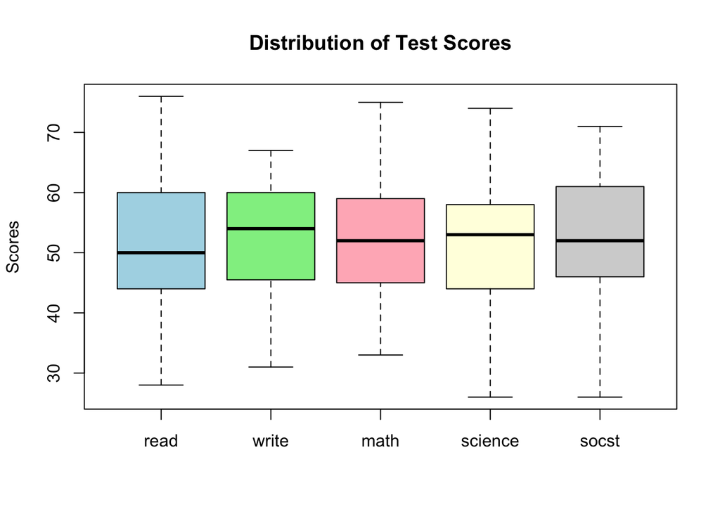

*Table 6. Table of 95% Confidence Intervals for each Standardized Test.*

```
##         Lower_CI Upper_CI
## Read       50.80    53.66
## Write      51.45    54.10
## Math       51.34    53.95
## Science    50.47    53.23
## Socst      50.91    53.90
```

Based on the 95% confidence intervals for each of the test scores we can make the following estimates about the larger population:

Regarding the standardized reading test scores we estimate with a 95% confidence that the average score in the student population will fall between 50.8 and 53.7 points. This suggests that the average performance on the reading test is relatively low, with a narrow range of possible scores.

The student’s math test scores had a 95% confidence interval for a mean score is between 51.3 and 54 points. Like their writing and math test scores we see similar trends of a moderate performance.

In science, the 95% confidence interval for the mean score falls between 50.5 and 53.2 points. The science test scores seem to be consistent with the reading scores, with a slightly lower average.

Finally, for social studies, the 95% confidence interval for the mean score is between 50.9 and 53.9 points. This suggests that social studies scores was in line with the other subjects, with the true population mean likely falling within this interval.